# Projekt 2, grupa 5, spółka Betacom

Karolina Szot, Justyna Wachowiak, Julia Pawluś

2024-10-11

## Opis badania

Celem badania jest wyznaczenie i porównanie prognoz cen oraz stóp zwrotu z uwzględnieniem różnych metod statystycznych.

W tym celu obliczono logarytmy cen i logarytmicznych stóp zwrotu, zbadano stacjonarność, dopasowano model do stóp zwrotu a następnie wysznaczono prognozy, stosując symulacje Monte Carlo oraz bootstrap. Na końcu przeprowadzono badanie ponownie, uwzględniając występowanie efektu ARCH.

W badaniu wykorzystano dane spółki BETACOM, ktróra została wybrana samodzielnie z ostatnich 20 spółek znajdujących się w rankingu WIG, gdyż po zostosowaniu wzoru z polecenia, numer ten nie występował już w rankingu.

## BETACOM

Dane wykorzystane w projekcie zostały pobrane ze strony *stooq.pl*. Obserwacje dotyczą spółki BETACOM, która działa w branży IT, tworząc oprogramowanie na zamówienie oraz integrując systemy informatyczne. Dane pochodzą z okresu od 1 września 2023 do 4 października 2024 i zawierają 276 obserwacji, gdzie dla każdej z nich odnotowane są wartości cen otwarcia, zamknięcia, najwyżjesz, najniższej oraz wolumenu.

```r
dane <- read.csv2("bcm_d.csv", sep = ",", dec = ".", header = T)
paged_table(dane)
```

| Data | Otwarcie | Najwyzszy | Najnizszy | Zamkniecie | Wolumen |
| --- | --- | --- | --- | --- | --- |
| 2023-09-01 | 4.52523 | 4.52523 | 4.46250 | 4.46250 | 318.050420 |
| 2023-09-04 | 4.48042 | 4.48042 | 4.48042 | 4.48042 | 11.159664 |
| 2023-09-05 | 4.52523 | 4.52523 | 4.52523 | 4.52523 | 2.231933 |
| 2023-09-06 | 4.52523 | 4.52523 | 4.28329 | 4.30120 | 470.937815 |
| 2023-09-07 | 4.52523 | 4.52523 | 4.28329 | 4.28329 | 107.132773 |
| 2023-09-08 | 4.52523 | 4.52523 | 4.46250 | 4.46250 | 253.324370 |
| 2023-09-11 | 4.46250 | 4.46250 | 4.46250 | 4.46250 | 178.554622 |
| 2023-09-12 | 4.52523 | 4.52523 | 4.24744 | 4.24744 | 2180.598319 |
| 2023-09-13 | 4.48042 | 4.48042 | 4.37289 | 4.37289 | 325.862185 |
| 2023-09-14 | 4.24744 | 4.37289 | 4.24744 | 4.24744 | 316.934454 |

[output cut: 266 more lines]

### Wyznaczenie logarytmicznych cen i stóp zwrotu

```r
df <- data.frame(Data = as.Date(dane$Data), Zamkniecie = dane$Zamkniecie, Zamkniecie_log = NA, Stopa_zwrotu_log = NA)
```

```r
# Log ceny
for (i in 1:nrow(df)){
  df[i, 3] <- log(df[i,2])
}

# Stopy zwrotu logarytmiczne
for (i in 2:nrow(df)){
  df[i, 4] <- log(df[i, 2]/df[i-1, 2])
}

new_df <- df[-1,]

# Nowe dane
paged_table(new_df)
```

|  | Data | Zamkniecie | Zamkniecie_log | Stopa_zwrotu_log |
| --- | --- | --- | --- | --- |
| 2 | 2023-09-04 | 4.48042 | 1.499717 | 0.004007645 |
| 3 | 2023-09-05 | 4.52523 | 1.509668 | 0.009951613 |
| 4 | 2023-09-06 | 4.30120 | 1.458894 | -0.050774351 |
| 5 | 2023-09-07 | 4.28329 | 1.454721 | -0.004172648 |
| 6 | 2023-09-08 | 4.46250 | 1.495709 | 0.040987741 |
| 7 | 2023-09-11 | 4.46250 | 1.495709 | 0.000000000 |
| 8 | 2023-09-12 | 4.24744 | 1.446316 | -0.049392699 |
| 9 | 2023-09-13 | 4.37289 | 1.475424 | 0.029107669 |
| 10 | 2023-09-14 | 4.24744 | 1.446316 | -0.029107669 |
| 11 | 2023-09-15 | 4.26536 | 1.450527 | 0.004210137 |

[output cut: 265 more lines]

### Podział danych na treningowe i testowe

Zgodnie z poleceniem zbiór danych został podzielony na dane treningowe, do końca września 2024 oraz testowe, za które odpowiadały dni 1-4 października 2024.

```r
train <- new_df[-((nrow(new_df)-3):nrow(new_df)), ]
test <-  tail(new_df, 4)

liczba_treningowych <- nrow(train)
liczba_testowych <- nrow(test)

#procent_treningowych <- round((liczba_treningowych / N),3) * 100
#procent_testowych <- round((liczba_testowych / N),3) * 100

#cat("Procent zbioru treningowego:", procent_treningowych, "%\n")
#cat("Procent zbioru testowego:", procent_testowych, "%\n")
```

## 1. Test ADF - badanie stacjonarności szeregów

H0: szereg jest niestacjonarny H1: szereg jest stacjonarny

```r
adf.test(train$Zamkniecie_log) # niestacjonarny
```

```
##
##  Augmented Dickey-Fuller Test
##
## data:  train$Zamkniecie_log
## Dickey-Fuller = -1.5302, Lag order = 6, p-value = 0.7739
## alternative hypothesis: stationary
```

```r
#  p-value = 0.7739 > 0.05

adf.test(train$Stopa_zwrotu_log) # stacjonarny
```

```
##
##  Augmented Dickey-Fuller Test
##
## data:  train$Stopa_zwrotu_log
## Dickey-Fuller = -6.1506, Lag order = 6, p-value = 0.01
## alternative hypothesis: stationary
```

```r
# p-value = 0.01 < 0.05
```

Z testów wynika, że logarytmiczne ceny są niestacjonarne, ponieważ p-value=0.7739, w związku z czym nie ma podstaw do odrzucenia H0. Natomiast, dla logarytmicznych stóp zwrotu p-value=0.01, zatem odrzucamy hipotezę zerową, czyli szereg jest stacjonarny.

## 2. Wybór modelu ARMA/ARIMA

```r
model <- auto.arima(train$Stopa_zwrotu_log)
model
```

```
## Series: train$Stopa_zwrotu_log
## ARIMA(0,0,1) with zero mean
##
## Coefficients:
##           ma1
##       -0.1515
## s.e.   0.0638
##
## sigma^2 = 0.0005685:  log likelihood = 628.48
## AIC=-1252.96   AICc=-1252.91   BIC=-1245.75
```

Najlepszy model dla logarytmicznych stóp zwrotu - ARIMA(0,0,1) Interpretacja ARMA(0,1): Model nie wykorzystuje przeszłych wartości szeregów czasowych do prognozowania przyszłych wartości, gdyż nie zawiera komponentu autoregresyjnego AR(0,1). Bieżąca wartość szeregu czasowego jest kombinacją obecnego błędu prognozy oraz wcześniejszego błędu prognozy.

### Badanie autokorelacji składników losowych

#### Wykres ACF

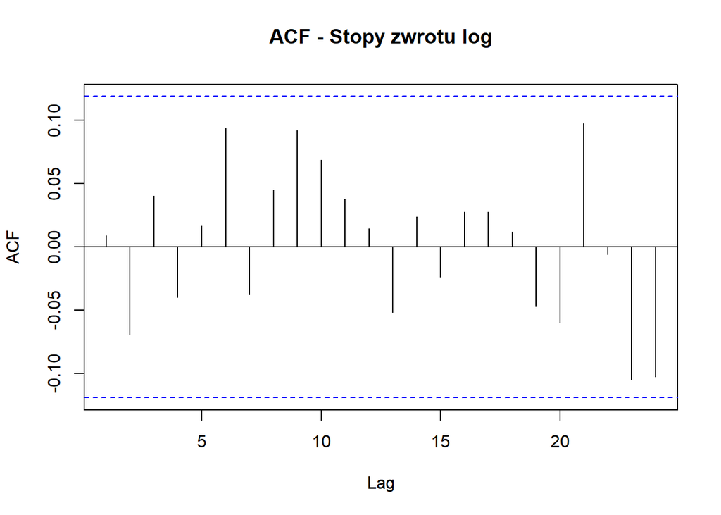

```r
# składnik losowy == reszty
reszty <- model$residuals

# autokorelacja
Acf(reszty, main="ACF - Stopy zwrotu log")
```

Na wykresie nie jest widoczne aby poszczególne wartości wykraczały poza progi, co oznacza że nie występuje autokorelacja.

#### Test Ljung-Boxa

H0: Brak autokorelacji H1: Występuje autokorelacja

```r
Box.test(reszty, lag = 1, type = "Ljung-Box")$p.value
```

```
## [1] 0.8797915
```

```r
# 0.8797915 > 0.05 brak autokorelacji
```

### Badanie istotności parametrów przy najwyższych opóźnieniach

```r
coeftest(model)
```

```
##
## z test of coefficients:
##
##      Estimate Std. Error z value Pr(>|z|)
## ma1 -0.151457   0.063768 -2.3751  0.01754 *
## ---
## Signif. codes:  0 '***' 0.001 '**' 0.01 '*' 0.05 '.' 0.1 ' ' 1
```

Parametr średniej ruchomej MA(1) w modelu ARIMA(0,0,1) jest istotny na poziomie 5%, więc w modelu uwzględniamy jedno opóźnienie.

### Badanie białego szumu

Aby reszty były białym szumem, muszą spełniać następujące warunki:

1. Wartość oczekiwana równa zero. E(x) = 0
2. Stała wariancja. var(x) = const
3. Brak autokorelacji. corr = 0

W naszym modelu: Na wcześniej przedstawionym wykresie ACF, jasno widać, że mamy brak autokorelacji w resztach modelu.

```r
cat("Średnia reszt: ", mean(reszty), "\n")
```

```
## Średnia reszt:  -7.003996e-05
```

Test t-studenta: H0: Średnia reszt jest równa zero. H1: Średnia reszt jest różna od zera.

```r
t.test(reszty, mu = 0) # p-value = 0.9615 -> H0: średnia reszt = 0
```

```
##
##  One Sample t-test
##
## data:  reszty
## t = -0.048357, df = 270, p-value = 0.9615
## alternative hypothesis: true mean is not equal to 0
## 95 percent confidence interval:
##  -0.002921598  0.002781518
## sample estimates:
##     mean of x
## -7.003996e-05
```

p-value jest większe niż poziom istotności (0.05), a zatem nie ma podstaw do odrzucenia hipotezy zerowej, co oznacza, że średnia reszt nie różni się istotnie od zera.

Badanie wariancji reszt:

```r
reszty_sq <- reszty^2
Box.test(reszty_sq, lag = 1, type = "Ljung-Box") # p-value = 0.1194 -> brak autokorelacji
```

```
##
##  Box-Ljung test
##
## data:  reszty_sq
## X-squared = 2.4256, df = 1, p-value = 0.1194
```

```r
# Test Arch na heteroskedastyczność
ArchTest(reszty, lags = 1) # p-value = 0.122 -> no ARCH effects
```

```
##
##  ARCH LM-test; Null hypothesis: no ARCH effects
##
## data:  reszty
## Chi-squared = 2.392, df = 1, p-value = 0.122
```

Z testu Ljung-Boxa p-value wynosi 0.1194, czyli jest większe niż przyjęty poziom istotności 0.05, stąd też nie ma podstaw do odrzucenia hipotezy zerowej o braku autokorelacji w kwadratach reszt. W teście ARCH p-value = 0.122, co również wskazuje na brak podstaw do odrzucenia hipotezy zerowej o braku efektów ARCH. Oznacza to, że nie występuje heteroskedastyczność w resztach modelu, czyli wariancja jest stała.

Reszty w tym modelu można uznać za biały szum.

## 3. Prognozy logarytmicznych stóp zwrotu, logarytmów cen i cen aż do 4 notowań.

Wybrany model z pkt.2 - ARMA(0,1). Wyznaczamy najlepszy model dla logarytmicznych cen:

```r
model_2 <- auto.arima(train$Zamkniecie_log)
model_2
```

```
## Series: train$Zamkniecie_log
## ARIMA(0,1,1)
##
## Coefficients:
##           ma1
##       -0.1513
## s.e.   0.0638
##
## sigma^2 = 0.0005706:  log likelihood = 625.68
## AIC=-1247.36   AICc=-1247.31   BIC=-1240.16
```

Wybieramy model ARIMA(0,1,1).

```r
stopy_zwr_model <- arima(train$Stopa_zwrotu_log, order=c(0,0,1))
ceny_log_model <- arima(train$Zamkniecie_log, order=c(0,1,1))
```

Zakładamy rozkład normalny dla logarytmicznych stóp zwrotu, czyli logarytmiczne ceny mają warunkowy rozkład normalmny. Zatem ceny mają rozkład logarytmicznie normalny.

#### Predykcje logarytmicznych stóp zwrotu

```r
forecast_values <- forecast(stopy_zwr_model, h=4)
predict <- as.data.frame(forecast_values)
real_values <- tail(test$Stopa_zwrotu_log, 4)

comparison <- data.frame(
  Actual = real_values,
  Forecast = predict$`Point Forecast`,
  Lower95 = predict$`Lo 95`,
  Upper95 = predict$`Hi 95`
)

paged_table(comparison)
```

| Actual | Forecast | Lower95 | Upper95 |
| --- | --- | --- | --- |
| 0.009049836 | -2.019691e-03 | -0.04866552 | 0.04462614 |
| -0.032039354 | -6.172218e-05 | -0.04723968 | 0.04711624 |
| 0.022989518 | -6.172218e-05 | -0.04723968 | 0.04711624 |
| 0.004535155 | -6.172218e-05 | -0.04723968 | 0.04711624 |

#### Predykcje logarytmicznych cen

```r
forecast_values <- forecast(ceny_log_model, h=4)
predict_2 <- as.data.frame(forecast_values)
real_values <- tail(test$Zamkniecie_log, 4)

comparison_2 <- data.frame(
  Actual = real_values,
  Forecast = predict_2$`Point Forecast`,
  Lower95 = predict_2$`Lo 95`,
  Upper95 = predict_2$`Hi 95`
)

paged_table(comparison_2)
```

| Actual | Forecast | Lower95 | Upper95 |
| --- | --- | --- | --- |
| 1.490654 | 1.47966 | 1.432930 | 1.526389 |
| 1.458615 | 1.47966 | 1.418369 | 1.540950 |
| 1.481605 | 1.47966 | 1.406657 | 1.552663 |
| 1.486140 | 1.47966 | 1.396580 | 1.562740 |

#### Predykcja cen. Zestawienie wszystkich predykcji wraz z przedziałami ufności

```r
predictions <- data.frame(
  Zamkniecie_pred = NA,
  Lower_cena = NA,
  Upper_cena = NA,
  Zamkniecie_log_pred = predict_2$`Point Forecast`,
  Lower_log_cena = predict_2$`Lo 95`,
  Upper_log_cena = predict_2$`Hi 95`,
  Stopa_zwrotu_log_pred = predict$`Point Forecast`,
  Lower_st_zw = predict$`Lo 95`,
  Upper_st_zw = predict$`Hi 95`
)


# Predykcja cen
for (i in 1:4){
  mi <- predictions[i,"Zamkniecie_log_pred"]

  temp_df <- as.data.frame(c(train$Zamkniecie_log, predictions$Zamkniecie_log[1:i]))
  colnames(temp_df) <- c("Zamkniecie_log_combined")

  # Odchylenie standardowe
  sigma <- sd(temp_df$Zamkniecie_log_combined)
  sigma2 <- sigma^2

  # Prognozowana cena
  predictions[i,"Zamkniecie_pred"] <- exp(mi+sigma2/2)

  z_value <- qnorm(0.975)
  # Obliczanie przedziałów ufności dla cen
  temp_df_2 <- as.data.frame(c(train$Zamkniecie, predictions$Zamkniecie_pred[1:i]))
  colnames(temp_df_2) <- c("Zamkniecie_combined")

  s <- sd(temp_df_2$Zamkniecie_combined)
  s2 <-s^2

  predictions[i, "Lower_cena"] <- exp(mi - z_value * sigma + 0.5 * s2)
  predictions[i, "Upper_cena"] <- exp(mi + z_value * sigma + 0.5 * s2)
}

paged_table(predictions)
```

| Zamkniecie_pred | Lower_cena | Upper_cena | Zamkniecie_log_pred | Lower_log_cena | Upper_log_cena | Stopa_zwrotu_log_pred | Lower_st_zw | Upper_st_zw |
| --- | --- | --- | --- | --- | --- | --- | --- | --- |
| 4.418662 | 4.094918 | 6.330950 | 1.47966 | 1.432930 | 1.526389 | -2.019691e-03 | -0.04866552 | 0.04462614 |
| 4.418619 | 4.094524 | 6.328149 | 1.47966 | 1.418369 | 1.540950 | -6.172218e-05 | -0.04723968 | 0.04711624 |
| 4.418576 | 4.094132 | 6.325347 | 1.47966 | 1.406657 | 1.552663 | -6.172218e-05 | -0.04723968 | 0.04711624 |
| 4.418532 | 4.093743 | 6.322543 | 1.47966 | 1.396580 | 1.562740 | -6.172218e-05 | -0.04723968 | 0.04711624 |

Prognozy modelu logarytmicznych stóp zwrotu są bliskie zera. Rzeczywiste wartości wykazują większą zmienność, ale mieszczą się w szerokich przedziałach ufności. Szerokie przedziały ufności wskazują na dużą niepewność prognoz. Prognozy modelu logarytmicznych cen są zbliżone do wartości 1.48 dla każdej obserwacji. Rzeczywiste wartości wykazują większą zmienność, ale wszystkie mieszczą się w szerokich przedziałach ufności. Prognozy dla cen zamknięcia są stabilne i zbliżone do wartości 4.418 dla każdej obserwacji, z szerokimi przedziałami ufności, co wskazuje na znaczną niepewność prognoz.

#### Porównanie rzeczywistych wartości z predykcjami

```r
result_df <- as.data.frame(cbind(test$Zamkniecie, predictions$Zamkniecie_pred, test$Zamkniecie_log, predictions$Zamkniecie_log, test$Stopa_zwrotu_log, predictions$Stopa_zwrotu_log_pred))

colnames(result_df) <- c("Zamkniecie","Zamkniecie_pred","Zamkniecie_log","Zamkniecie_log_pred","Stopa_zwrotu_log","Stopa_zwrotu_log_pred")

paged_table(result_df)
```

| Zamkniecie | Zamkniecie_pred | Zamkniecie_log | Zamkniecie_log_pred | Stopa_zwrotu_log | Stopa_zwrotu_log_pred |
| --- | --- | --- | --- | --- | --- |
| 4.44 | 4.418662 | 1.490654 | 1.47966 | 0.009049836 | -2.019691e-03 |
| 4.30 | 4.418619 | 1.458615 | 1.47966 | -0.032039354 | -6.172218e-05 |
| 4.40 | 4.418576 | 1.481605 | 1.47966 | 0.022989518 | -6.172218e-05 |
| 4.42 | 4.418532 | 1.486140 | 1.47966 | 0.004535155 | -6.172218e-05 |

Model prognozuje ceny zamknięcia oraz logarytmiczne ceny z wynikami zbliżonymi do rzeczywistych, ale występują pewne różnice. Prognozowane ceny zamknięcia (ok. 4.418) są stabilne, podczas gdy rzeczywiste ceny są bardziej zróżnicowane (od 4.30 do 4.44). Podobnie, prognozy logarytmicznych cen są stałe (1.47966) i nie odzwierciedlają w pełni zmienności rzeczywistych wartości (od 1.459 do 1.491).

Prognozowane logarytmiczne stopy zwrotu są bliskie zeru, co sugeruje, że model przewiduje niewielką zmienność. Jednak rzeczywiste stopy zwrotu wykazują większe odchylenia (od -0.032 do 0.023).

## 4. Monte Carlo

Na podstawie rozkładu reszt modelu dopasowanego w pkt.2. symulacyjnie (za pomocą metody Monte Carlo) wyznaczyć prognozy logarytmów cen i samych cen aż do 4 notowań. Na tej podstawie wyznaczyć także 95% przedziały ufności dla wartości logarytmów cen i samych cen. Uzyskane w ten sposób wyniki porównać z prognozami z punktu 3.

```r
reszty_2 <- residuals(ceny_log_model)
mu <- 0
sigma <- sd(reszty_2)

n_symulacji <- 1000
n_prognoz <- 4

prognozy_log <- matrix(0, nrow = n_symulacji, ncol = n_prognoz)

ostatni_log <- tail(train$Zamkniecie_log, 1)


set.seed(123)
for (j in 1:n_symulacji) {
  prognozy_log[j, 1] <- ostatni_log + rnorm(1, mean = mu, sd = sigma)
  for (i in 2:n_prognoz) {
    prognozy_log[j, i] <- prognozy_log[j, i - 1] + rnorm(1, mean = mu, sd = sigma)
  }
}

prognozy_ceny <- exp(prognozy_log + (sigma^2 / 2))

log_forecast_mean <- apply(prognozy_log, 2, mean)
log_ci_lower <- apply(prognozy_log, 2, function(x) quantile(x, probs = 0.025))
log_ci_upper <- apply(prognozy_log, 2, function(x) quantile(x, probs = 0.975))

cena_forecast_mean <- apply(prognozy_ceny, 2, mean)
cena_ci_lower <- apply(prognozy_ceny, 2, function(x) quantile(x, probs = 0.025))
cena_ci_upper <- apply(prognozy_ceny, 2, function(x) quantile(x, probs = 0.975))

log_ceny_results <- data.frame(
  Horyzont_Prognozy = 1:n_prognoz,
  Srednia_Log_Ceny = log_forecast_mean,
  Dolny_Przedzial95_Log = log_ci_lower,
  Gorny_Przedzial95_Log = log_ci_upper
)

ceny_results <- data.frame(
  Horyzont_Prognozy = 1:n_prognoz,
  Srednia_Ceny = cena_forecast_mean,
  Dolny_Przedzial95_Cena = cena_ci_lower,
  Gorny_Przedzial95_Cena = cena_ci_upper
)
```

#### Prognozy logarytmów cen

```r
paged_table(log_ceny_results)
```

| Horyzont_Prognozy | Srednia_Log_Ceny | Dolny_Przedzial95_Log | Gorny_Przedzial95_Log |
| --- | --- | --- | --- |
| 1 | 1.481821 | 1.434118 | 1.527883 |
| 2 | 1.481509 | 1.419332 | 1.542673 |
| 3 | 1.481845 | 1.406184 | 1.559003 |
| 4 | 1.482304 | 1.394393 | 1.571149 |

#### Prognozy cen

```r
paged_table(ceny_results)
```

| Horyzont_Prognozy | Srednia_Ceny | Dolny_Przedzial95_Cena | Gorny_Przedzial95_Cena |
| --- | --- | --- | --- |
| 1 | 4.403395 | 4.197134 | 4.609722 |
| 2 | 4.403020 | 4.135531 | 4.678406 |
| 3 | 4.405682 | 4.081515 | 4.755428 |
| 4 | 4.408967 | 4.033672 | 4.813543 |

## 5. Metody bootstrapowe

Na podstawie oszacowanych reszt, za pomocą metod bootstrapowych wyznaczyć prognozy logarytmów cen i samych cen aż do 4 sesji. Wyznaczyć także 95% przedziały ufności dla wartości logarytmów cen i samych cen. Uzyskane w ten sposób wyniki porównać z prognozami z punktu 3 i 4.

```r
set.seed(123)

n_bootstrap <- 1000
n_prognoz <- 4
reszty_2 <- residuals(ceny_log_model)

prognozy_log_bootstrap <- matrix(0, nrow = n_bootstrap, ncol = n_prognoz)

ostatni_log <- tail(train$Zamkniecie_log, 1)


for (j in 1:n_bootstrap) {
  prognozy_log_bootstrap[j, 1] <- ostatni_log + sample(reszty_2, 1, replace = TRUE)
  for (i in 2:n_prognoz) {
    prognozy_log_bootstrap[j, i] <- prognozy_log_bootstrap[j, i - 1] + sample(reszty_2, 1, replace = TRUE)
  }
}

sigma <- sd(reszty_2)
prognozy_ceny_bootstrap <- exp(prognozy_log_bootstrap  + (sigma^2 / 2))

log_forecast_mean_bootstrap <- apply(prognozy_log_bootstrap, 2, mean)
log_ci_lower_bootstrap <- apply(prognozy_log_bootstrap, 2, function(x) quantile(x, probs = 0.025))
log_ci_upper_bootstrap <- apply(prognozy_log_bootstrap, 2, function(x) quantile(x, probs = 0.975))

cena_forecast_mean_bootstrap <- apply(prognozy_ceny_bootstrap, 2, mean)
cena_ci_lower_bootstrap <- apply(prognozy_ceny_bootstrap, 2, function(x) quantile(x, probs = 0.025))
cena_ci_upper_bootstrap <- apply(prognozy_ceny_bootstrap, 2, function(x) quantile(x, probs = 0.975))

log_ceny_bootstrap_results <- data.frame(
  Horyzont_Prognozy = 1:n_prognoz,
  Srednia_Log_Ceny = log_forecast_mean_bootstrap,
  Dolny_Przedzial95_Log = log_ci_lower_bootstrap,
  Gorny_Przedzial95_Log = log_ci_upper_bootstrap
)

ceny_bootstrap_results <- data.frame(
  Horyzont_Prognozy = 1:n_prognoz,
  Srednia_Ceny = cena_forecast_mean_bootstrap,
  Dolny_Przedzial95_Cena = cena_ci_lower_bootstrap,
  Gorny_Przedzial95_Cena = cena_ci_upper_bootstrap
)
```

#### Prognozy logarytmów cen

```r
paged_table(log_ceny_bootstrap_results)
```

| Horyzont_Prognozy | Srednia_Log_Ceny | Dolny_Przedzial95_Log | Gorny_Przedzial95_Log |
| --- | --- | --- | --- |
| 1 | 1.480872 | 1.431598 | 1.525159 |
| 2 | 1.481549 | 1.408626 | 1.552283 |
| 3 | 1.482125 | 1.390502 | 1.571106 |
| 4 | 1.482079 | 1.376407 | 1.578221 |

#### Prognozy cen

```r
paged_table(ceny_bootstrap_results)
```

| Horyzont_Prognozy | Srednia_Ceny | Dolny_Przedzial95_Cena | Gorny_Przedzial95_Cena |
| --- | --- | --- | --- |
| 1 | 4.399285 | 4.186573 | 4.597182 |
| 2 | 4.403485 | 4.091494 | 4.723583 |
| 3 | 4.407410 | 4.018008 | 4.813336 |
| 4 | 4.408191 | 3.961770 | 4.847702 |

## 6. Model ARMA-GARCH

Badanie z punktów 3-5 powtórzyć przy założeniu występowania efektu ARCH, tzn. dla odpowiedniego modelu ARMA-GARCH. Przeprowadzić też test występowania efektu ARCH.

#### Test ARCH

1. Reszty z modelu logarytmicznych stóp zwrotu

```r
reszty_st_zw <- residuals(stopy_zwr_model)
ArchTest(reszty_st_zw, lags = 1)
```

```
##
##  ARCH LM-test; Null hypothesis: no ARCH effects
##
## data:  reszty_st_zw
## Chi-squared = 2.4053, df = 1, p-value = 0.1209
```

2. Reszty z modelu logarytmicznych cen

```r
reszty_log <- residuals(ceny_log_model)
ArchTest(reszty_log, lags = 1)
```

```
##
##  ARCH LM-test; Null hypothesis: no ARCH effects
##
## data:  reszty_log
## Chi-squared = 2.3861, df = 1, p-value = 0.1224
```

W kolejnych krokach tworzymy dwa modele ARMA-GARCH dla logarytmicznych stóp zwrotu oraz logarytmicznych cen. Wykorzystujemy do tego modele ARMA(0,1) i GARCH(1,1). Następnie na ich podstawie zgodnie z podpunktem 3 wyznaczamy predykcje oraz przedziały ufności dla logarytmicznych stóp zwrotu, logarytmicznych cen oraz cen.

#### Badanie z pkt. 3

```r
# Dla arima(0,0,1), garch(1,1)
spec <- ugarchspec(
  variance.model = list(model = "sGARCH", garchOrder = c(1, 1)),
  mean.model = list(armaOrder = c(0, 1), include.mean = TRUE),
  distribution.model = "norm"
)

fit <- ugarchfit(spec = spec, data = train$Stopa_zwrotu_log)
```

```r
# dla arima(0,1,1), garch(1,1)
spec2 <- ugarchspec(
  variance.model = list(model = "sGARCH", garchOrder = c(1, 1)),
  mean.model = list(armaOrder = c(0, 1), include.mean = TRUE, arfima = TRUE),
  distribution.model = "norm"
)

fit2 <- ugarchfit(spec = spec2, data = train$Zamkniecie_log)
```

1. Predykcje oraz wyznaczone przedziały ufności:

```r
# Prognoza logarytmicznych stóp zwrotu
prognoza_stop_zwr <- ugarchforecast(fit, n.ahead = 4)
prognozy_stop_zwr <- data.frame(Prognoza_Stopy_Zwrotu=prognoza_stop_zwr@forecast$seriesFor,Wariancja_Stopy_Zwrotu=prognoza_stop_zwr@forecast$sigmaFor)
colnames(prognozy_stop_zwr) <- c("Prognoza_Stopy_Zwrotu", "Wariancja_Stopy_Zwrotu")

# Prognoza logarytmicznych cen
prognoza_log_cena <- ugarchforecast(fit2, n.ahead = 4)
prognoza_log_cena <- data.frame(Prognoza_Log_Cena=prognoza_log_cena@forecast$seriesFor,Wariancja_Log=prognoza_log_cena@forecast$sigmaFor)
colnames(prognoza_log_cena) <- c("Prognoza_Log_Cena","Wariancja_Log")

predictions_pkt6 <- data.frame(
  Zamkniecie_pred = NA,
  Lower_cena = NA,
  Upper_cena = NA,
  Zamkniecie_log_pred = prognoza_log_cena$Prognoza_Log_Cena,
  Lower_log_cena = NA,
  Upper_log_cena = NA,
  Stopa_zwrotu_log_pred = prognozy_stop_zwr$Prognoza_Stopy_Zwrotu,
  Lower_st_zw = NA,
  Upper_st_zw = NA
)

for (i in 1:4){
  mu <- predictions_pkt6[i,"Zamkniecie_log_pred"]
  sigma2 <- prognoza_log_cena[i, "Wariancja_Log"]
  sigma <- sqrt(sigma2)

  # Prognozowana cena
  predictions_pkt6[i,"Zamkniecie_pred"] <- exp(mu+0.5*sigma2)

  z_value <- qnorm(0.975)
  # Obliczanie przedziałów ufności dla logarytmicznych cen
  predictions_pkt6[i, "Lower_log_cena"] <- mu - z_value * sqrt(sigma2)
  predictions_pkt6[i, "Upper_log_cena"] <- mu + z_value * sqrt(sigma2)

  # Obliczanie przedziałów ufności dla cen
  predictions_pkt6[i, "Lower_cena"] <- exp(mu - z_value * sigma + 0.5 * sigma2)
  predictions_pkt6[i, "Upper_cena"] <- exp(mu + z_value * sigma + 0.5 * sigma2)

  # Obliczanie przedziałów ufności dla logarytmicznych stóp zwrotu
  mu_2 <- predictions_pkt6[i,"Stopa_zwrotu_log_pred"]
  s2 <- prognozy_stop_zwr[i, "Wariancja_Stopy_Zwrotu"]

  predictions_pkt6[i, "Lower_st_zw"] <- mu_2 - z_value * sqrt(s2)
  predictions_pkt6[i, "Upper_st_zw"] <- mu_2 + z_value * sqrt(s2)
}

paged_table(predictions_pkt6)
```

| Zamkniecie_pred | Lower_cena | Upper_cena | Zamkniecie_log_pred | Lower_log_cena | Upper_log_cena | Stopa_zwrotu_log_pred | Lower_st_zw | Upper_st_zw |
| --- | --- | --- | --- | --- | --- | --- | --- | --- |
| 4.473901 | 3.365184 | 5.947904 | 1.487705 | 1.202927 | 1.772483 | -0.0012052701 | -0.3101205 | 0.3077100 |
| 4.483932 | 3.366920 | 5.971524 | 1.489816 | 1.203314 | 1.776318 | 0.0004694976 | -0.3087640 | 0.3097030 |
| 4.494209 | 3.369108 | 5.995032 | 1.491983 | 1.203842 | 1.780125 | 0.0004694976 | -0.3090750 | 0.3100140 |
| 4.503172 | 3.370563 | 6.016371 | 1.493858 | 1.204156 | 1.783560 | 0.0004694976 | -0.3093789 | 0.3103179 |

2. Porównanie rzeczywistych wartości z predykcjami:

```r
# Porównanie rzeczywistych wartości z predykcjami
result_df_pkt6 <- as.data.frame(cbind(test$Zamkniecie, predictions_pkt6$Zamkniecie_pred, test$Zamkniecie_log, predictions_pkt6$Zamkniecie_log_pred, test$Stopa_zwrotu_log, predictions_pkt6$Stopa_zwrotu_log_pred))

colnames(result_df_pkt6) <- c("Zamkniecie","Zamkniecie_pred","Zamkniecie_log","Zamkniecie_log_pred","Stopa_zwrotu_log","Stopa_zwrotu_log_pred")

paged_table(result_df_pkt6)
```

| Zamkniecie | Zamkniecie_pred | Zamkniecie_log | Zamkniecie_log_pred | Stopa_zwrotu_log | Stopa_zwrotu_log_pred |
| --- | --- | --- | --- | --- | --- |
| 4.44 | 4.473901 | 1.490654 | 1.487705 | 0.009049836 | -0.0012052701 |
| 4.30 | 4.483932 | 1.458615 | 1.489816 | -0.032039354 | 0.0004694976 |
| 4.40 | 4.494209 | 1.481605 | 1.491983 | 0.022989518 | 0.0004694976 |
| 4.42 | 4.503172 | 1.486140 | 1.493858 | 0.004535155 | 0.0004694976 |

#### Badanie z pkt. 4 - Monte Carlo

```r
reszty_fit2 <- residuals(fit2)
mu <- 0
sigma <- sd(reszty_fit2)

n_symulacji <- 1000
n_prognoz <- 4

prognozy_log <- matrix(0, nrow = n_symulacji, ncol = n_prognoz)

ostatni_log <- tail(train$Zamkniecie_log, 1)


set.seed(123)
for (j in 1:n_symulacji) {
  prognozy_log[j, 1] <- ostatni_log + rnorm(1, mean = mu, sd = sigma)
  for (i in 2:n_prognoz) {
    prognozy_log[j, i] <- prognozy_log[j, i - 1] + rnorm(1, mean = mu, sd = sigma)
  }
}

prognozy_ceny <- exp(prognozy_log + (sigma^2 / 2))

log_forecast_mean <- apply(prognozy_log, 2, mean)
log_ci_lower <- apply(prognozy_log, 2, function(x) quantile(x, probs = 0.025))
log_ci_upper <- apply(prognozy_log, 2, function(x) quantile(x, probs = 0.975))

cena_forecast_mean <- apply(prognozy_ceny, 2, mean)
cena_ci_lower <- apply(prognozy_ceny, 2, function(x) quantile(x, probs = 0.025))
cena_ci_upper <- apply(prognozy_ceny, 2, function(x) quantile(x, probs = 0.975))

log_ceny_results <- data.frame(
  Horyzont_Prognozy = 1:n_prognoz,
  Srednia_Log_Ceny = log_forecast_mean,
  Dolny_Przedzial95_Log = log_ci_lower,
  Gorny_Przedzial95_Log = log_ci_upper
)

ceny_results <- data.frame(
  Horyzont_Prognozy = 1:n_prognoz,
  Srednia_Ceny = cena_forecast_mean,
  Dolny_Przedzial95_Cena = cena_ci_lower,
  Gorny_Przedzial95_Cena = cena_ci_upper
)
```

1. Prognozy logarytmów cen:

```r
paged_table(log_ceny_results)
```

| Horyzont_Prognozy | Srednia_Log_Ceny | Dolny_Przedzial95_Log | Gorny_Przedzial95_Log |
| --- | --- | --- | --- |
| 1 | 1.481854 | 1.427040 | 1.534781 |
| 2 | 1.481495 | 1.410050 | 1.551775 |
| 3 | 1.481880 | 1.394943 | 1.570538 |
| 4 | 1.482408 | 1.381395 | 1.584496 |

2. Prognozy cen

```r
paged_table(ceny_results)
```

| Horyzont_Prognozy | Srednia_Ceny | Dolny_Przedzial95_Cena | Gorny_Przedzial95_Cena |
| --- | --- | --- | --- |
| 1 | 4.404319 | 4.167912 | 4.642051 |
| 2 | 4.404060 | 4.097698 | 4.721614 |
| 3 | 4.407322 | 4.036259 | 4.811042 |
| 4 | 4.411314 | 3.981943 | 4.878661 |

#### Badanie z pkt. 5 - metody bootstrapowe

```r
set.seed(123)

reszty_fit2 <- residuals(fit2)

prognozy_log_bootstrap <- matrix(0, nrow = n_bootstrap, ncol = n_prognoz)

ostatni_log <- tail(train$Zamkniecie_log, 1)


for (j in 1:n_bootstrap) {
  prognozy_log_bootstrap[j, 1] <- ostatni_log + sample(reszty_fit2, 1, replace = TRUE)
  for (i in 2:n_prognoz) {
    prognozy_log_bootstrap[j, i] <- prognozy_log_bootstrap[j, i - 1] + sample(reszty_fit2, 1, replace = TRUE)
  }
}

sigma <- sd(reszty_fit2)
prognozy_ceny_bootstrap <- exp(prognozy_log_bootstrap  + (sigma^2 / 2))

log_forecast_mean_bootstrap <- apply(prognozy_log_bootstrap, 2, mean)
log_ci_lower_bootstrap <- apply(prognozy_log_bootstrap, 2, function(x) quantile(x, probs = 0.025))
log_ci_upper_bootstrap <- apply(prognozy_log_bootstrap, 2, function(x) quantile(x, probs = 0.975))

cena_forecast_mean_bootstrap <- apply(prognozy_ceny_bootstrap, 2, mean)
cena_ci_lower_bootstrap <- apply(prognozy_ceny_bootstrap, 2, function(x) quantile(x, probs = 0.025))
cena_ci_upper_bootstrap <- apply(prognozy_ceny_bootstrap, 2, function(x) quantile(x, probs = 0.975))

log_ceny_bootstrap_results <- data.frame(
  Horyzont_Prognozy = 1:n_prognoz,
  Srednia_Log_Ceny = log_forecast_mean_bootstrap,
  Dolny_Przedzial95_Log = log_ci_lower_bootstrap,
  Gorny_Przedzial95_Log = log_ci_upper_bootstrap
)

ceny_bootstrap_results <- data.frame(
  Horyzont_Prognozy = 1:n_prognoz,
  Srednia_Ceny = cena_forecast_mean_bootstrap,
  Dolny_Przedzial95_Cena = cena_ci_lower_bootstrap,
  Gorny_Przedzial95_Cena = cena_ci_upper_bootstrap
)
```

1. Bootstrapowe prognozy logarytmów cen

```r
paged_table(log_ceny_bootstrap_results)
```

| Horyzont_Prognozy | Srednia_Log_Ceny | Dolny_Przedzial95_Log | Gorny_Przedzial95_Log |
| --- | --- | --- | --- |
| 1 | 1.481560 | 1.405154 | 1.543733 |
| 2 | 1.483155 | 1.398496 | 1.558583 |
| 3 | 1.484455 | 1.383046 | 1.582469 |
| 4 | 1.486273 | 1.378212 | 1.591517 |

2. Bootstrapowe prognozy cen

```r
paged_table(ceny_bootstrap_results)
```

| Horyzont_Prognozy | Srednia_Ceny | Dolny_Przedzial95_Cena | Gorny_Przedzial95_Cena |
| --- | --- | --- | --- |
| 1 | 4.403114 | 4.077685 | 4.683793 |
| 2 | 4.411595 | 4.050627 | 4.753865 |
| 3 | 4.419048 | 3.988525 | 4.868785 |
| 4 | 4.428264 | 3.969293 | 4.913038 |

#### Porównanie wyników z poprzednimi prognozami logarytmicznych cen i cen

1. Porównanie logarytmicznych cen

```r
final_comparison_log_ceny <- as.data.frame(cbind(
  test$Zamkniecie_log,
  predictions_pkt6$Zamkniecie_log_pred,
  log_ceny_results$Srednia_Log_Ceny,
  log_ceny_bootstrap_results$Srednia_Log_Ceny
  ))

colnames(final_comparison_log_ceny) <- c("Rzeczywiste_ceny_log","Ceny_log_pred_3","Ceny_log_pred_4","Ceny_log_pred_5")

paged_table(final_comparison_log_ceny)
```

| Rzeczywiste_ceny_log | Ceny_log_pred_3 | Ceny_log_pred_4 | Ceny_log_pred_5 |
| --- | --- | --- | --- |
| 1.490654 | 1.487705 | 1.481854 | 1.481560 |
| 1.458615 | 1.489816 | 1.481495 | 1.483155 |
| 1.481605 | 1.491983 | 1.481880 | 1.484455 |
| 1.486140 | 1.493858 | 1.482408 | 1.486273 |

Wartości prognozowane są bliskie rzeczywistym wartościom logarytmicznym cen, jednakże każda z prognoz (3, 4, 5) wykazuje pewne odchylenia w stosunku do rzeczywistych cen. ‘Ceny_log_pred_3’ wydaje się najbliższa rzeczywistej wartości dla pierwszej predykcji, gdzie różnica wynosi około 0.003. Jednakże w kolejnych wierszach te różnice się zwiększają. ‘Ceny_log_pred_4’ i ‘Ceny_log_pred_5’ są mniej oddalone od rzeczywistych cen logarytmicznych. Jedynie w pierwszej prognozie różnice są gorsze niż w kolumnie ‘Ceny_log_pred_3’.

Podsumowując, prognozy wyznaczone za pomocą metody Monte Carlo - ‘Ceny_log_pred_4’, wydają się być najbliższe rzeczywistości. Niemniej jednak, różnice są na tyle małe, że wszystkie trzy poziomy prognoz mają podobną jakość przewidywania.

2. Porównanie cen

```r
final_comparison_ceny <- as.data.frame(cbind(
  test$Zamkniecie,
  predictions_pkt6$Zamkniecie_pred,
  ceny_results$Srednia_Ceny,
  ceny_bootstrap_results$Srednia_Ceny
  ))

colnames(final_comparison_ceny) <- c("Rzeczywiste_ceny","Ceny_pred_3","Ceny_pred_4","Ceny_pred_5")

paged_table(final_comparison_ceny)
```

| Rzeczywiste_ceny | Ceny_pred_3 | Ceny_pred_4 | Ceny_pred_5 |
| --- | --- | --- | --- |
| 4.44 | 4.473901 | 4.404319 | 4.403114 |
| 4.30 | 4.483932 | 4.404060 | 4.411595 |
| 4.40 | 4.494209 | 4.407322 | 4.419048 |
| 4.42 | 4.503172 | 4.411314 | 4.428264 |

Model prognozy ‘Ceny_pred_4’ wydaje się być najbardziej zbliżony w odniesieniu do rzeczywistych cen. Niemniej jedank, przewidywane wartości w dalszym ciągu nie są w pełni zadowalające. ‘Ceny_pred_3’ są bliskie rzeczywistym wartościom, ale widoczna jest tendencja do zawyżania prognoz. ‘Ceny_pred_5’ są podobne do prognoz ‘Ceny_pred_4’. Są w miarę zbliżone do rzeczywistych wartości. Jedynie druga predykcja odbiega od rzeczywistej wartości o ok. 0.12, natomiast pozostałe oscylują w granicach błędu 0.008-0.04.

Źródła: https://www.investopedia.com/terms/m/montecarlosimulation.asp https://strefainwestorow.pl/notowania/spolki/PLBTCOM00016